# Case Study: Chi-Squared Goodness of Fit Test

## Introduction

This case study explores the application of the chi-squared goodness of fit test on data sourced from the direct marketing campaigns of a Portuguese banking institution.

**Data Source**: [Bank Market Data](https://ljkelly3141.github.io/ABE-Book/data/bank-full.csv) provided by S. Moro, P. Cortez, and P. Rita (2014)[^1].

### Case Background

- Objective: Verify if the bank’s client job distribution mirrors the general job distribution in society.
- Importance: Reflects the diversity and appeal of the bank’s services.

### Data Description

Variables of focus from the dataset:

| Variable | Description |
| --- | --- |
| age | Age of the client |
| job | Type of job |
| marital | Marital status |
| education | Level of education |
| default | Has credit in default? |
| balance | Average yearly balance, in euros |
| … | … |

- The ‘job’ variable is categorical with 12 categories.

## **Step 1: Load the Data and Inspect the ‘job’ Variable**

```r
# Load Packages
pacman::p_load("tidyverse")

# Load the dataset
bank <-
  read.csv("https://ljkelly3141.github.io/ABE-Book/data/bank-full.csv",
           sep = ';')

# Examine 'job' distribution
job.table <- table(bank$job)
as.data.frame(job.table) %>%
  rename("Job Categories" = "Var1")
```

```
##    Job Categories Freq
## 1          admin. 5171
## 2     blue-collar 9732
## 3    entrepreneur 1487
## 4       housemaid 1240
## 5      management 9458
## 6         retired 2264
## 7   self-employed 1579
## 8        services 4154
## 9         student  938
## 10     technician 7597
## 11     unemployed 1303
## 12        unknown  288
```

## **Step 2: Hypotheses Formulation**

- Null hypothesis ($H_0$): Observed job distribution = Expected job distribution
- Alternate hypothesis ($H_a$): Observed job distribution ≠ Expected job distribution

The observed and expected job distribution is

```r
freq <-data.frame(category = names(job.table),
                  expected.frequency = c(4521, 11303, 1356, 1356, 9042, 2261, 1356, 4521, 904, 6782, 1356, 453)
                  )
freq$expected.frequency <- freq$expected.frequency/sum(freq$expected.frequency)
freq$observed.frequency <- as.data.frame(job.table)$Freq/sum(job.table)

freq
```

```
##         category expected.frequency observed.frequency
## 1         admin.         0.09999779        0.114374820
## 2    blue-collar         0.25000553        0.215257349
## 3   entrepreneur         0.02999270        0.032890226
## 4      housemaid         0.02999270        0.027426954
## 5     management         0.19999558        0.209196877
## 6        retired         0.05000995        0.050076309
## 7  self-employed         0.02999270        0.034925129
## 8       services         0.09999779        0.091880295
## 9        student         0.01999513        0.020747163
## 10    technician         0.15000774        0.168034328
## 11    unemployed         0.02999270        0.028820420
## 12       unknown         0.01001969        0.006370131
```

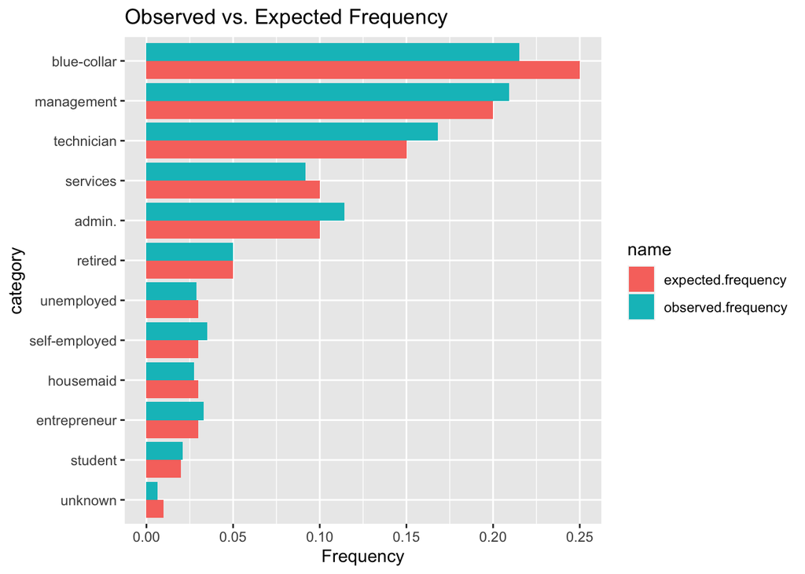

```r
freq %>%
  mutate(category = fct_reorder(category, .$expected.frequency) ) %>%
  pivot_longer(-category) %>%
  ggplot(aes(x = category, y = value, fill = name)) +
  geom_col(position = "dodge") +
  labs(title = "Observed vs. Expected Frequency", y = "Frequency") +
  coord_flip()
```

## **Step 3: Expected Frequencies and Degrees of Freedom**

1. Determine number of job categories:

```r
n.categories <- length(job.table)
n.categories
```

```
## [1] 12
```

2. Compute expected count for each job category:

```r
expected.counts <- freq$expected.frequency * sum(job.table)
names(expected.counts) <- names(job.table)
expected.counts %>% as.data.frame()
```

```
##                   .
## admin.         4521
## blue-collar   11303
## entrepreneur   1356
## housemaid      1356
## management     9042
## retired        2261
## self-employed  1356
## services       4521
## student         904
## technician     6782
## unemployed     1356
## unknown         453
```

## **Step 4: Calculate the Chi-Square Statistic**

```r
observed.counts <- table(bank$job)
chi.sq <- sum((observed.counts - expected.counts)^2 / expected.counts)
chi.sq
```

```
## [1] 581.3817
```

## **Step 5: Determine the P-value**

```r
p.value <- pchisq(chi.sq, df = n.categories - 1, lower.tail = FALSE)
p.value
```

```
## [1] 1.342451e-117
```

## **Step 6: Result Interpretation**

Given the p-value, if it’s less than a significance level (e.g., 0.05), then we reject $H_0$. This would indicate that the bank’s client job distribution does not reflect the expected distribution.

## **Step 7: How to do this in practice**

```r
chisq.test(job.table,p=freq$expected.frequency)
```

```
##
##  Chi-squared test for given probabilities
##
## data:  job.table
## X-squared = 581.38, df = 11, p-value < 2.2e-16
```

## References

[^1]: Moro, S., Cortez, P., & Rita, P. (2014). A Data-Driven Approach to Predict the Success of Bank Telemarketing. Decision Support Systems, Elsevier, 62:22-31. Retrieved from https://archive.ics.uci.edu/ml/datasets/bank+marketing